# Hypothesis Testing

Max Johansson

Spring 2024

# 1. Introduction

In this project I perform two hypothesis tests on simulated data. In the first hypothesis test I consider the mean income of the individuals in the data, using the null hypothesis that the mean income of the population is equal to 40.000 $ income units against the alternative hypothesis that it is not equal to 40.000 $. In the second hypothesis test I consider the mean income between two groups: unmarried and married individuals, testing the null hypothesis that the means of the groups are equal in the population against the alternative hypothesis that the means of the groups are not equal in the population.

# 2. Data

I use a ISLR2 data set called ‘Credit’. The variables I consider for this project is the continuous ‘income’ variable and the binary ‘married’ variable. The income variable is measured in thousands of $, so 40.000 $ is registered as 40.

```r
# Setup: data and packages:
library(ISLR2)

# Data file:
df <- ISLR2::Credit
```

# 3. Results

$$H_0: \mu = 40 \\ H_1: \mu \neq
40$$

```r
# The mean and the standard deviation of the variable in the data:
m_hat_inc <- mean(df$Income)
sd_hat_inc <- sd(df$Income)

# Setting the null hypothesis:
m0_inc <- 40

# Setting the significance level:
a <- 0.05

# Setting the sample size:
n <- nrow(df)

# The degrees of freedom:
d_free <- n - 1

# Critical t value:
t_crit <- qt(1- a/2, df = d_free)

# The t-statistic is:
t_stat <- (m_hat_inc - m0_inc)/ (sd_hat_inc / sqrt(n))

# Upper and lower limits:
ul <- m0_inc + t_crit*(sd_hat_inc / sqrt(n))
ll <- m0_inc - t_crit*(sd_hat_inc/ sqrt(n))

# The p-value of the outcome:
p_val <- 2 * (1- pt(q = abs(t_stat), df = d_free))

# Print the results:
cat("Sample mean:",
    round(m_hat_inc,3),
    "and 95% CI estimate:",
    round(ll,3),
    ",",
    round(ul,3), "\n")
```

```
## Sample mean: 45.219 and 95% CI estimate: 36.536 , 43.464
```

```r
cat("t-statistic:",
    round(t_crit,3),
    "and p-value:",
    round(p_val, 3),"\n")
```

```
## t-statistic: 1.966 and p-value: 0.003
```

I visualize the results by plotting the distribution of the income variable together with the null hypothesis mean, the sample mean and the critical limits. At a 5% significance level, the null hypothesis that the mean of income is equal to 40 is rejected in favor of the alternative hypothesis that the mean is not equal to 40.

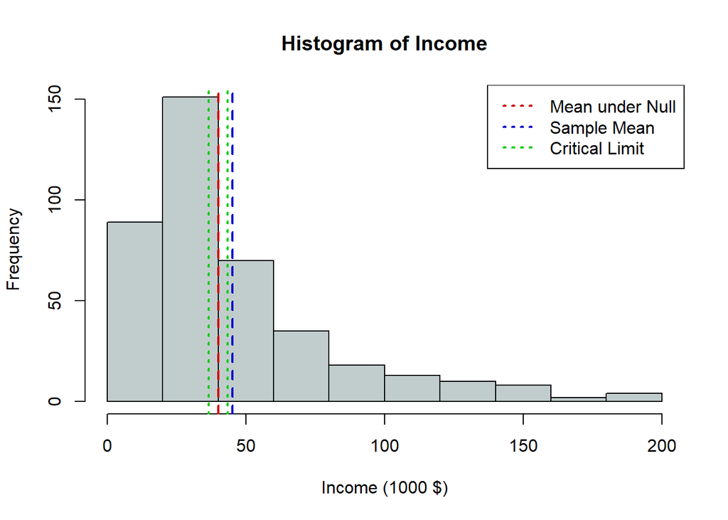

```r
# Histogram
hist(df$Income, main = "Histogram of Income", xlab = "Income (1000 $)", ylab = "Frequency", col = "azure3")
abline(v = m0_inc, col = "red3", lwd = 2, lty = 2, label = "Mean under Null Hypothesis")
abline(v = m_hat_inc, col = "blue3", lwd = 2, lty = 2, label = "Sample Mean")
abline(v = c(ul, ll), col = "green3",lwd = 2, lty = 3)
legend("topright", legend = c("Mean under Null", "Sample Mean", "Critical Limit"), col = c("red3","blue3", "green3"), lwd = 2, lty = 3)
```

## 3.2. Two Sided Hypothesis Test - Two Samples

I now investigate if there a significant difference in income between unmarried people and married people. The hypotheses are:

$$H_0: \mu_{u} = \mu_{m} \\ H_1: \mu_{u}
\neq \mu_{m}$$

According to my results, the p-value associated with the t-statistic is greater than 5%, so the null hypothesis that the means of unmarried and married individuals is equal is not rejected.

```r
# Income values per marital status:
vals_unmarried <- subset(df$Income, df$Married == "No")
vals_married <- subset(df$Income, df$Married == "Yes")

# Mean Income of non-married and married groups:
m_unmarried <- mean(vals_unmarried)
m_married <- mean(vals_married)

# The difference:
m_diff <- m_unmarried - m_married

# Standard deviation of the groups:
sd_unmarried <- sd(vals_unmarried)
sd_married <- sd(vals_married)

# Number of observations in each group:
n_unmarried <- length(vals_unmarried)
n_married <- length(vals_married)

# Pooled standard deviation:
pooled_sd <- sqrt(((n_unmarried - 1) * sd_unmarried^2 + (n_married -1) * sd_unmarried^2) / (n_unmarried + n_married - 2))

# t statistic:
t <- m_diff / (pooled_sd * sqrt(1/n_unmarried + 1/ n_married))

# Degrees of freedom:
d_fr <- n_unmarried + n_married - 2

# P-value of t-statistic:
p <- 2 * (1- pt(abs(t), df = d_fr))

# Lower and Upper limit for the difference
ll <- m_diff - qt(0.975, d_fr) * pooled_sd * sqrt(1/n_unmarried + 1/n_married)
ul <- m_diff +  qt(0.975, d_fr)* pooled_sd * sqrt(1/n_unmarried + 1/n_married)

# Print the results:
cat("Difference in means:",
    round(m_diff,3),
    "and 95% CI:",
    round(ll,3),
    ",",
    round(ul,3),
    "\n")
```

```
## Difference in means: -2.576 and 95% CI: -9.11 , 3.958
```

```r
cat("t-statistic:",
    round(t,3),
    "and p-value:",
    round(p,3),
    "\n")
```

```
## t-statistic: -0.775 and p-value: 0.439
```

# 4. Findings

My results indicate that the mean of the income variable is not 40, and that the mean incomes of the unmarried and married subgroups are not significantly different from each other.

# 5. Libraries

ISLR2: https://cran.r-project.org/package=ISLR2